# NORBIS GENESTAT course, R intro

Øystein Haaland, Miriam Gjerdevik, Julia Romanowska

2020-11-23

# PART 1

> Note: throughout the course, we will mix between the `base` R notation and `tidyverse` notation because it is not always the easiest to use the `tidyverse` way on these genetic data.

```r
library(dplyr)
library(tidyr)
library(readr)
library(snpStats)
```

## SNPs and alleles

1. Read data from file `data_a_intro_R.dat` and save it to `obj`:

```r
obj <- read_table2("data_a_intro_R.dat")
```

2. Look at the data: check the class, dimensions and print the first part of the data:

```r
class(obj)
```

```
## [1] "spec_tbl_df" "tbl_df"      "tbl"         "data.frame"
```

```r
obj
```

```
## # A tibble: 900 x 48
##    ID    cc.status snp_1.1 snp_1.2 snp_2.1 snp_2.2 snp_3.1 snp_3.2 snp_4.1
##    <chr>     <dbl>   <dbl>   <dbl>   <dbl>   <dbl>   <dbl>   <dbl>   <dbl>
##  1 ID_3          1       2       2       1       2       2       2      NA
##  2 ID_8          1       2       2       1       2       2       1      NA
##  3 ID_19         1       2       2       1       1       2       2       2
##  4 ID_25         1       1       2       1       1       1       1       2
##  5 ID_31         1       2       1       2       1       2       2      NA
##  6 ID_36         1       2       2       1       2       2       2       1
##  7 ID_41         1       2       2       2       2       2       2       1
##  8 ID_68         1       1       2       2       2       2       2       2
##  9 ID_81         1       2       2       1       1       2       2      NA
## 10 ID_84         1       2       2       2       1       2       2      NA
## # … with 890 more rows, and 39 more variables: snp_4.2 <dbl>, snp_5.1 <dbl>,
## #   snp_5.2 <dbl>, snp_6.1 <dbl>, snp_6.2 <dbl>, snp_7.1 <dbl>, snp_7.2 <dbl>,
## #   snp_8.1 <dbl>, snp_8.2 <dbl>, snp_9.1 <dbl>, snp_9.2 <dbl>, snp_10.1 <dbl>,
## #   snp_10.2 <dbl>, snp_11.1 <dbl>, snp_11.2 <dbl>, snp_12.1 <dbl>,
## #   snp_12.2 <dbl>, snp_13.1 <dbl>, snp_13.2 <dbl>, snp_14.1 <dbl>,
## #   snp_14.2 <dbl>, snp_15.1 <dbl>, snp_15.2 <dbl>, snp_16.1 <dbl>,
## #   snp_16.2 <dbl>, snp_17.1 <dbl>, snp_17.2 <dbl>, snp_18.1 <dbl>,
## #   snp_18.2 <dbl>, snp_19.1 <dbl>, snp_19.2 <dbl>, snp_20.1 <dbl>,
## #   snp_20.2 <dbl>, snp_21.1 <dbl>, snp_21.2 <dbl>, snp_22.1 <dbl>,
## #   snp_22.2 <dbl>, snp_23.1 <dbl>, snp_23.2 <dbl>
```

3. Using the data
- Accessing the column named `cc.status`, using the `$` sign (0 codes for control and 1 for case)

```r
cc.status <- obj$cc.status
class(cc.status)
```

```
## [1] "numeric"
```

```r
mean(cc.status)
```

```
## [1] 0.5555556
```

```r
summary(cc.status)
```

```
##    Min. 1st Qu.  Median    Mean 3rd Qu.    Max.
##  0.0000  0.0000  1.0000  0.5556  1.0000  1.0000
```

```r
table(cc.status)
```

```
## cc.status
##   0   1
## 400 500
```

- Accessing the first SNP

```r
snp1 <- obj %>%
  select(snp_1.1, snp_1.2)
snp1
```

```
## # A tibble: 900 x 2
##    snp_1.1 snp_1.2
##      <dbl>   <dbl>
##  1       2       2
##  2       2       2
##  3       2       2
##  4       1       2
##  5       2       1
##  6       2       2
##  7       2       2
##  8       1       2
##  9       2       2
## 10       2       2
## # … with 890 more rows
```

- Tabulating the first SNP

```r
table(snp1$snp_1.1)
```

```
##
##   1   2
## 101 799
```

```r
table(snp1$snp_1.2)
```

```
##
##   1   2
## 108 792
```

```r
table(snp1)
```

```
##        snp_1.2
## snp_1.1   1   2
##       1  15  86
##       2  93 706
```

- Divide by number of indivdiuals (function `nrow` will count all the rows, i.e., individuals) and check whether it sums up to 100%

```r
table(snp1)/nrow(snp1)
```

```
##        snp_1.2
## snp_1.1          1          2
##       1 0.01666667 0.09555556
##       2 0.10333333 0.78444444
```

```r
sum(table(snp1)/nrow(snp1))
```

```
## [1] 1
```

- Rounding to two decimal points - still sums up to 100%!

```r
round(table(snp1)/nrow(snp1), 2)
```

```
##        snp_1.2
## snp_1.1    1    2
##       1 0.02 0.10
##       2 0.10 0.78
```

```r
sum(round(table(snp1)/nrow(snp1), 2))
```

```
## [1] 1
```

- Tabulate SNP8

```r
snp8 <- obj %>%
  select(snp_8.1, snp_8.2)
snp8
```

```
## # A tibble: 900 x 2
##    snp_8.1 snp_8.2
##      <dbl>   <dbl>
##  1       2       2
##  2      -9      -9
##  3       2       2
##  4       2       2
##  5      -9      -9
##  6       2       2
##  7       2       2
##  8       2       2
##  9       2       2
## 10       2       2
## # … with 890 more rows
```

```r
table(snp8$snp_8.1)
```

[output not shown]

```r
table(snp8$snp_8.2)
```

[output not shown]

```r
table(snp8)
```

[output not shown]

- `-9` means missing. Replace `-9` with `NA` (not available) in the entire dataset.

```r
obj[obj == -9] <- NA
snp8 <- obj %>%
  select(snp_8.1, snp_8.2)
```

### Exercise 1

Fill the space between apostrophes with your code and click the green arrow to check how it evaluates.

1.1 Tabulate SNP8 again.

1.2 What is the distribution of alleles?

1.3 Why does it not sum to 100%? Hint: `?table`

## Missing data, apply, which, names, any, remove rows and columns from object

1. Set the argument `useNA = "ifany"` to make the distribution of alleles in SNP8 sum up to 100%

```r
table(snp8, useNA = "ifany")/nrow(snp8)
```

```
##        snp_8.2
## snp_8.1          1          2       <NA>
##    1    0.03555556 0.13666667 0.00000000
##    2    0.16666667 0.57666667 0.00000000
##    <NA> 0.00000000 0.00000000 0.08444444
```

```r
sum(table(snp8, useNA = "ifany")/nrow(snp8))
```

```
## [1] 1
```

2. Find those columns in `obj` that contain missing data

```r
na.obj <- is.na(obj)
head(na.obj)
```

```
##         ID cc.status snp_1.1 snp_1.2 snp_2.1 snp_2.2 snp_3.1 snp_3.2 snp_4.1
## [1,] FALSE     FALSE   FALSE   FALSE   FALSE   FALSE   FALSE   FALSE    TRUE
## [2,] FALSE     FALSE   FALSE   FALSE   FALSE   FALSE   FALSE   FALSE    TRUE
## [3,] FALSE     FALSE   FALSE   FALSE   FALSE   FALSE   FALSE   FALSE   FALSE
## [4,] FALSE     FALSE   FALSE   FALSE   FALSE   FALSE   FALSE   FALSE   FALSE
## [5,] FALSE     FALSE   FALSE   FALSE   FALSE   FALSE   FALSE   FALSE    TRUE
## [6,] FALSE     FALSE   FALSE   FALSE   FALSE   FALSE   FALSE   FALSE   FALSE
##      snp_4.2 snp_5.1 snp_5.2 snp_6.1 snp_6.2 snp_7.1 snp_7.2 snp_8.1 snp_8.2
## [1,]    TRUE   FALSE   FALSE   FALSE   FALSE   FALSE   FALSE   FALSE   FALSE
## [2,]    TRUE   FALSE   FALSE   FALSE   FALSE   FALSE   FALSE    TRUE    TRUE
## [3,]   FALSE   FALSE   FALSE   FALSE   FALSE   FALSE   FALSE   FALSE   FALSE
## [4,]   FALSE   FALSE   FALSE   FALSE   FALSE   FALSE   FALSE   FALSE   FALSE
## [5,]    TRUE   FALSE   FALSE   FALSE   FALSE   FALSE   FALSE    TRUE    TRUE
## [6,]   FALSE   FALSE   FALSE   FALSE   FALSE   FALSE   FALSE   FALSE   FALSE
##      snp_9.1 snp_9.2 snp_10.1 snp_10.2 snp_11.1 snp_11.2 snp_12.1 snp_12.2
```

[output cut: 27 more lines]

```r
head(na.obj)*1
```

```
##      ID cc.status snp_1.1 snp_1.2 snp_2.1 snp_2.2 snp_3.1 snp_3.2 snp_4.1
## [1,]  0         0       0       0       0       0       0       0       1
## [2,]  0         0       0       0       0       0       0       0       1
## [3,]  0         0       0       0       0       0       0       0       0
## [4,]  0         0       0       0       0       0       0       0       0
## [5,]  0         0       0       0       0       0       0       0       1
## [6,]  0         0       0       0       0       0       0       0       0
##      snp_4.2 snp_5.1 snp_5.2 snp_6.1 snp_6.2 snp_7.1 snp_7.2 snp_8.1 snp_8.2
## [1,]       1       0       0       0       0       0       0       0       0
## [2,]       1       0       0       0       0       0       0       1       1
## [3,]       0       0       0       0       0       0       0       0       0
## [4,]       0       0       0       0       0       0       0       0       0
## [5,]       1       0       0       0       0       0       0       1       1
## [6,]       0       0       0       0       0       0       0       0       0
##      snp_9.1 snp_9.2 snp_10.1 snp_10.2 snp_11.1 snp_11.2 snp_12.1 snp_12.2
```

[output cut: 27 more lines]

- Function `is.na` returns `TRUE` or `FALSE` for each value, but we can translate it to 0’s and 1’s, which is easier to handle when calculating some properties of each SNP.
3. Identify proportion of missing data for each SNP

```r
na.snp <- apply(na.obj, 2, mean)
na.snp
```

```
##         ID  cc.status    snp_1.1    snp_1.2    snp_2.1    snp_2.2    snp_3.1
## 0.00000000 0.00000000 0.00000000 0.00000000 0.00000000 0.00000000 0.00000000
##    snp_3.2    snp_4.1    snp_4.2    snp_5.1    snp_5.2    snp_6.1    snp_6.2
## 0.00000000 0.51000000 0.51000000 0.00000000 0.00000000 0.00000000 0.00000000
##    snp_7.1    snp_7.2    snp_8.1    snp_8.2    snp_9.1    snp_9.2   snp_10.1
## 0.00000000 0.00000000 0.08444444 0.08444444 0.00000000 0.00000000 0.00000000
##   snp_10.2   snp_11.1   snp_11.2   snp_12.1   snp_12.2   snp_13.1   snp_13.2
## 0.00000000 0.00000000 0.00000000 0.07888889 0.07888889 0.00000000 0.00000000
##   snp_14.1   snp_14.2   snp_15.1   snp_15.2   snp_16.1   snp_16.2   snp_17.1
## 0.06000000 0.06000000 0.00000000 0.00000000 0.01000000 0.01000000 0.00000000
##   snp_17.2   snp_18.1   snp_18.2   snp_19.1   snp_19.2   snp_20.1   snp_20.2
## 0.00000000 0.00000000 0.00000000 0.00000000 0.00000000 0.00000000 0.00000000
##   snp_21.1   snp_21.2   snp_22.1   snp_22.2   snp_23.1   snp_23.2
## 0.07111111 0.07111111 0.06111111 0.06111111 0.08444444 0.08444444
```

- Which SNPs have more than 7% missing?

```r
na.snp.07 <- which(na.snp > 0.07)
na.snp.07
```

```
##  snp_4.1  snp_4.2  snp_8.1  snp_8.2 snp_12.1 snp_12.2 snp_21.1 snp_21.2
##        9       10       17       18       25       26       43       44
## snp_23.1 snp_23.2
##       47       48
```

```r
names(na.snp.07)
```

```
##  [1] "snp_4.1"  "snp_4.2"  "snp_8.1"  "snp_8.2"  "snp_12.1" "snp_12.2"
##  [7] "snp_21.1" "snp_21.2" "snp_23.1" "snp_23.2"
```

- Look at first 10 rows of SNPs with more than 7% missing

```r
obj %>% select(!!names(na.snp.07))
```

```
## # A tibble: 900 x 10
##    snp_4.1 snp_4.2 snp_8.1 snp_8.2 snp_12.1 snp_12.2 snp_21.1 snp_21.2 snp_23.1
##      <dbl>   <dbl>   <dbl>   <dbl>    <dbl>    <dbl>    <dbl>    <dbl>    <dbl>
##  1      NA      NA       2       2        2        2        1        2        2
##  2      NA      NA      NA      NA        2        2        2        2        2
##  3       2       2       2       2        2        1        2        1        2
##  4       2       2       2       2        2        2        2        2        2
##  5      NA      NA      NA      NA       NA       NA        2        2        2
##  6       1       2       2       2        2        1        2        2        2
##  7       1       2       2       2        2        2        2        2       NA
##  8       2       2       2       2        2        2       NA       NA        2
##  9      NA      NA       2       2        2        2        2        2        2
## 10      NA      NA       2       2        2        2        2        2        2
## # … with 890 more rows, and 1 more variable: snp_23.2 <dbl>
```

- Which SNPs have any missing data?

```r
apply(na.obj, 2, any)
```

```
##        ID cc.status   snp_1.1   snp_1.2   snp_2.1   snp_2.2   snp_3.1   snp_3.2
##     FALSE     FALSE     FALSE     FALSE     FALSE     FALSE     FALSE     FALSE
##   snp_4.1   snp_4.2   snp_5.1   snp_5.2   snp_6.1   snp_6.2   snp_7.1   snp_7.2
##      TRUE      TRUE     FALSE     FALSE     FALSE     FALSE     FALSE     FALSE
##   snp_8.1   snp_8.2   snp_9.1   snp_9.2  snp_10.1  snp_10.2  snp_11.1  snp_11.2
##      TRUE      TRUE     FALSE     FALSE     FALSE     FALSE     FALSE     FALSE
##  snp_12.1  snp_12.2  snp_13.1  snp_13.2  snp_14.1  snp_14.2  snp_15.1  snp_15.2
##      TRUE      TRUE     FALSE     FALSE      TRUE      TRUE     FALSE     FALSE
##  snp_16.1  snp_16.2  snp_17.1  snp_17.2  snp_18.1  snp_18.2  snp_19.1  snp_19.2
##      TRUE      TRUE     FALSE     FALSE     FALSE     FALSE     FALSE     FALSE
##  snp_20.1  snp_20.2  snp_21.1  snp_21.2  snp_22.1  snp_22.2  snp_23.1  snp_23.2
##     FALSE     FALSE      TRUE      TRUE      TRUE      TRUE      TRUE      TRUE
```

We can do the same in two different ways:

- directly on the original data set:

```r
apply(is.na(obj), 2, any)
```

```
##        ID cc.status   snp_1.1   snp_1.2   snp_2.1   snp_2.2   snp_3.1   snp_3.2
##     FALSE     FALSE     FALSE     FALSE     FALSE     FALSE     FALSE     FALSE
##   snp_4.1   snp_4.2   snp_5.1   snp_5.2   snp_6.1   snp_6.2   snp_7.1   snp_7.2
##      TRUE      TRUE     FALSE     FALSE     FALSE     FALSE     FALSE     FALSE
##   snp_8.1   snp_8.2   snp_9.1   snp_9.2  snp_10.1  snp_10.2  snp_11.1  snp_11.2
##      TRUE      TRUE     FALSE     FALSE     FALSE     FALSE     FALSE     FALSE
##  snp_12.1  snp_12.2  snp_13.1  snp_13.2  snp_14.1  snp_14.2  snp_15.1  snp_15.2
##      TRUE      TRUE     FALSE     FALSE      TRUE      TRUE     FALSE     FALSE
##  snp_16.1  snp_16.2  snp_17.1  snp_17.2  snp_18.1  snp_18.2  snp_19.1  snp_19.2
##      TRUE      TRUE     FALSE     FALSE     FALSE     FALSE     FALSE     FALSE
##  snp_20.1  snp_20.2  snp_21.1  snp_21.2  snp_22.1  snp_22.2  snp_23.1  snp_23.2
##     FALSE     FALSE      TRUE      TRUE      TRUE      TRUE      TRUE      TRUE
```

- and an advanced version, using a self-written function (useful if you must create your own code that is executed on all columns):

```r
apply(obj, 2, function(x){
  any(is.na(x))
})
```

```
##        ID cc.status   snp_1.1   snp_1.2   snp_2.1   snp_2.2   snp_3.1   snp_3.2
##     FALSE     FALSE     FALSE     FALSE     FALSE     FALSE     FALSE     FALSE
##   snp_4.1   snp_4.2   snp_5.1   snp_5.2   snp_6.1   snp_6.2   snp_7.1   snp_7.2
##      TRUE      TRUE     FALSE     FALSE     FALSE     FALSE     FALSE     FALSE
##   snp_8.1   snp_8.2   snp_9.1   snp_9.2  snp_10.1  snp_10.2  snp_11.1  snp_11.2
##      TRUE      TRUE     FALSE     FALSE     FALSE     FALSE     FALSE     FALSE
##  snp_12.1  snp_12.2  snp_13.1  snp_13.2  snp_14.1  snp_14.2  snp_15.1  snp_15.2
##      TRUE      TRUE     FALSE     FALSE      TRUE      TRUE     FALSE     FALSE
##  snp_16.1  snp_16.2  snp_17.1  snp_17.2  snp_18.1  snp_18.2  snp_19.1  snp_19.2
##      TRUE      TRUE     FALSE     FALSE     FALSE     FALSE     FALSE     FALSE
##  snp_20.1  snp_20.2  snp_21.1  snp_21.2  snp_22.1  snp_22.2  snp_23.1  snp_23.2
##     FALSE     FALSE      TRUE      TRUE      TRUE      TRUE      TRUE      TRUE
```

- Remove SNPs with more than 7% missing:

```r
obj <- obj %>%
  select(-!!names(na.snp.07))
obj
```

```
## # A tibble: 900 x 38
##    ID    cc.status snp_1.1 snp_1.2 snp_2.1 snp_2.2 snp_3.1 snp_3.2 snp_5.1
##    <chr>     <dbl>   <dbl>   <dbl>   <dbl>   <dbl>   <dbl>   <dbl>   <dbl>
##  1 ID_3          1       2       2       1       2       2       2       1
##  2 ID_8          1       2       2       1       2       2       1       2
##  3 ID_19         1       2       2       1       1       2       2       2
##  4 ID_25         1       1       2       1       1       1       1       2
##  5 ID_31         1       2       1       2       1       2       2       2
##  6 ID_36         1       2       2       1       2       2       2       1
##  7 ID_41         1       2       2       2       2       2       2       2
##  8 ID_68         1       1       2       2       2       2       2       1
##  9 ID_81         1       2       2       1       1       2       2       2
## 10 ID_84         1       2       2       2       1       2       2       1
## # … with 890 more rows, and 29 more variables: snp_5.2 <dbl>, snp_6.1 <dbl>,
## #   snp_6.2 <dbl>, snp_7.1 <dbl>, snp_7.2 <dbl>, snp_9.1 <dbl>, snp_9.2 <dbl>,
## #   snp_10.1 <dbl>, snp_10.2 <dbl>, snp_11.1 <dbl>, snp_11.2 <dbl>,
## #   snp_13.1 <dbl>, snp_13.2 <dbl>, snp_14.1 <dbl>, snp_14.2 <dbl>,
## #   snp_15.1 <dbl>, snp_15.2 <dbl>, snp_16.1 <dbl>, snp_16.2 <dbl>,
## #   snp_17.1 <dbl>, snp_17.2 <dbl>, snp_18.1 <dbl>, snp_18.2 <dbl>,
## #   snp_19.1 <dbl>, snp_19.2 <dbl>, snp_20.1 <dbl>, snp_20.2 <dbl>,
## #   snp_22.1 <dbl>, snp_22.2 <dbl>
```

### Exercise 2

2.1 Which individuals have any missing data? (Use `apply` and `obj`, not `na.obj`)

```r
which(apply(obj, 1, function(x){
    ...
}))
```

2.2 Keep individuals with less than 10% missing. Hint: First identify the rows with more than 10% missing, and then remove those.

```r
more10.missing <- which(apply(obj, 1, function(x){
    sum(is.na(x)) > length(x)/10
}))
obj.less10missing <- ...
obj.less10missing
```

## Merging matrices

1. Start with the original dataset

```r
obj <- read_table2("data_a_intro_R.dat")
```

2. `data_b_intro_R.dat` contains data on SNP24. Combine the previous dataset and this new SNP (`bind_cols` combines *columnwise*).

```r
snp24 <- read_table2("data_b_intro_R.dat")
snp24
```

```
## # A tibble: 900 x 2
##    snp_24.1 snp_24.2
##       <dbl>    <dbl>
##  1        2        2
##  2        2        2
##  3        2        2
##  4        2        2
##  5        2        2
##  6        2        2
##  7        2        2
##  8        2        2
##  9        2        2
## 10        1        2
## # … with 890 more rows
```

```r
obj <- obj %>%
  bind_cols(snp24)
obj
```

```
## # A tibble: 900 x 50
##    ID    cc.status snp_1.1 snp_1.2 snp_2.1 snp_2.2 snp_3.1 snp_3.2 snp_4.1
##    <chr>     <dbl>   <dbl>   <dbl>   <dbl>   <dbl>   <dbl>   <dbl>   <dbl>
##  1 ID_3          1       2       2       1       2       2       2      NA
##  2 ID_8          1       2       2       1       2       2       1      NA
##  3 ID_19         1       2       2       1       1       2       2       2
##  4 ID_25         1       1       2       1       1       1       1       2
##  5 ID_31         1       2       1       2       1       2       2      NA
##  6 ID_36         1       2       2       1       2       2       2       1
##  7 ID_41         1       2       2       2       2       2       2       1
##  8 ID_68         1       1       2       2       2       2       2       2
##  9 ID_81         1       2       2       1       1       2       2      NA
## 10 ID_84         1       2       2       2       1       2       2      NA
## # … with 890 more rows, and 41 more variables: snp_4.2 <dbl>, snp_5.1 <dbl>,
## #   snp_5.2 <dbl>, snp_6.1 <dbl>, snp_6.2 <dbl>, snp_7.1 <dbl>, snp_7.2 <dbl>,
## #   snp_8.1 <dbl>, snp_8.2 <dbl>, snp_9.1 <dbl>, snp_9.2 <dbl>, snp_10.1 <dbl>,
## #   snp_10.2 <dbl>, snp_11.1 <dbl>, snp_11.2 <dbl>, snp_12.1 <dbl>,
## #   snp_12.2 <dbl>, snp_13.1 <dbl>, snp_13.2 <dbl>, snp_14.1 <dbl>,
## #   snp_14.2 <dbl>, snp_15.1 <dbl>, snp_15.2 <dbl>, snp_16.1 <dbl>,
## #   snp_16.2 <dbl>, snp_17.1 <dbl>, snp_17.2 <dbl>, snp_18.1 <dbl>,
## #   snp_18.2 <dbl>, snp_19.1 <dbl>, snp_19.2 <dbl>, snp_20.1 <dbl>,
## #   snp_20.2 <dbl>, snp_21.1 <dbl>, snp_21.2 <dbl>, snp_22.1 <dbl>,
## #   snp_22.2 <dbl>, snp_23.1 <dbl>, snp_23.2 <dbl>, snp_24.1 <dbl>,
## #   snp_24.2 <dbl>
```

### Exercise 3

3.1 Add extra individuals (rows!) from `data_c_intro_R.dat` (with function `bind_rows`).

## Save and load objects

```r
write_delim(obj, path = "data_prep_R.dat", col_names = TRUE)

save(obj, file = "obj.RData")
rm(obj)
ls()
```

```
## [1] "cc.status" "na.obj"    "na.snp"    "na.snp.07" "snp1"      "snp24"
## [7] "snp8"
```

```r
load("obj.RData")
ls()
```

```
## [1] "cc.status" "na.obj"    "na.snp"    "na.snp.07" "obj"       "snp1"
## [7] "snp24"     "snp8"
```

## Packages

One of the strengths of R is the vast number of packages that can be installed at no cost.

1. Installing package(s)

```r
install.packages("Haplin)
```

2. Loading a package

```r
library(Haplin)
```

3. Help function for entire package

```r
help(package = "Haplin")
```

## Save and load workspace.

This saves the entire content of the memory, so that one can get back to work where they’d finished. Note that this does not re-load libraries, so one needs to run all the necessary `library` commands before or after loading a new workspace.

```r
save.image("genestat.RData")

load("genestat.RData")
```

# PART 2

We are now starting to work on real genotype data!

PLINK (Will get back to this in other lectures)

The files `data.ped` and `data.map` contain information about the genotype and phenotype, and about the SNPs, respectively, for a dataset with families (mother, father and a child), where the child had an oral cleft.

1. Show the first 10 lines of `data.map`

```r
read_table2("data.map", col_names = FALSE)
```

```
## # A tibble: 429 x 3
##       X1 X2       X3
##    <dbl> <chr> <dbl>
##  1     1 rs1       0
##  2     1 rs3       0
##  3     1 rs5       0
##  4     1 rs6       0
##  5     1 rs7       0
##  6     1 rs8       0
##  7     1 rs9       0
##  8     1 rs10      0
##  9     1 rs11      0
## 10     1 rs12      0
## # … with 419 more rows
```

```r
read_table2("data.ped", col_names = FALSE, n_max = 20)
```

```
## # A tibble: 20 x 864
##       X1 X2    X3    X4       X5    X6 X7    X8    X9    X10   X11   X12   X13
##    <dbl> <chr> <chr> <chr> <dbl> <dbl> <chr> <chr> <chr> <chr> <chr> <chr> <chr>
##  1     1 1_1   1_3   1_2       2     1 G     G     T     A     A     T     C
##  2     1 1_2   0     0         2     0 G     G     T     A     A     T     G
##  3     1 1_3   0     0         1     1 G     G     T     A     A     T     C
##  4     2 2_1   2_3   2_2       1     0 G     G     T     A     A     T     G
##  5     2 2_2   0     0         2     0 G     G     A     A     T     T     G
##  6     2 2_3   0     0         1     1 0     0     0     0     0     0     0
##  7     3 3_1   3_3   3_2       1     0 G     G     A     A     T     T     G
##  8     3 3_2   0     0         2     1 G     G     A     A     T     T     G
##  9     3 3_3   0     0         1     0 G     G     A     A     T     T     C
## 10     4 4_1   4_3   4_2       1     1 G     G     T     A     A     T     G
## 11     4 4_2   0     0         2     0 G     G     T     A     A     T     G
## 12     4 4_3   0     0         1     0 G     G     A     A     T     T     G
## 13     5 5_1   5_3   5_2       2     1 G     G     T     A     T     T     G
## 14     5 5_2   0     0         2     0 G     G     A     A     T     T     G
## 15     5 5_3   0     0         1     1 G     G     T     A     A     T     G
## 16     6 6_1   6_3   6_2       1     1 G     G     A     A     T     T     0
## 17     6 6_2   0     0         2     1 G     G     A     A     A     T     G
## 18     6 6_3   0     0         1     0 0     0     0     0     0     0     0
## 19     7 7_1   7_3   7_2       2     1 G     G     T     A     A     T     G
## 20     7 7_2   0     0         2     1 G     G     T     A     A     T     G
## # … with 851 more variables: X14 <chr>, X15 <chr>, X16 <chr>, X17 <chr>,
## #   X18 <chr>, X19 <chr>, X20 <chr>, X21 <chr>, X22 <chr>, X23 <chr>,
## #   X24 <chr>, X25 <chr>, X26 <chr>, X27 <chr>, X28 <chr>, X29 <chr>,
## #   X30 <chr>, X31 <chr>, X32 <chr>, X33 <chr>, X34 <chr>, X35 <chr>,
## #   X36 <chr>, X37 <chr>, X38 <chr>, X39 <chr>, X40 <chr>, X41 <chr>,
## #   X42 <chr>, X43 <chr>, X44 <chr>, X45 <chr>, X46 <chr>, X47 <chr>,
## #   X48 <chr>, X49 <chr>, X50 <chr>, X51 <chr>, X52 <chr>, X53 <chr>,
## #   X54 <chr>, X55 <chr>, X56 <chr>, X57 <chr>, X58 <chr>, X59 <chr>,
## #   X60 <chr>, X61 <chr>, X62 <chr>, X63 <chr>, X64 <chr>, X65 <chr>,
## #   X66 <chr>, X67 <chr>, X68 <chr>, X69 <chr>, X70 <chr>, X71 <chr>,
## #   X72 <chr>, X73 <chr>, X74 <chr>, X75 <chr>, X76 <chr>, X77 <chr>,
## #   X78 <chr>, X79 <chr>, X80 <chr>, X81 <chr>, X82 <chr>, X83 <chr>,
## #   X84 <chr>, X85 <chr>, X86 <chr>, X87 <chr>, X88 <chr>, X89 <chr>,
## #   X90 <chr>, X91 <chr>, X92 <chr>, X93 <chr>, X94 <chr>, X95 <chr>,
## #   X96 <chr>, X97 <chr>, X98 <chr>, X99 <chr>, X100 <chr>, X101 <chr>,
## #   X102 <chr>, X103 <chr>, X104 <chr>, X105 <chr>, X106 <chr>, X107 <chr>,
## #   X108 <chr>, X109 <chr>, X110 <chr>, X111 <chr>, X112 <chr>, X113 <chr>, …
```

PED-format:

| FAMILY_ID | ID_CHILD | ID_DAD | ID_MOM | SEX | CC | GENOTYPES |
| --- | --- | --- | --- | --- | --- | --- |
| 1 | 1_1 | 1_3 | 1_2 | 2 | 1 | G G T A A T C G C G G A … |
| 1 | 1_2 | 0 | 0 | 2 | 0 | G G T A A T G G G G A A … |
| 1 | 1_3 | 0 | 0 | 1 | 1 | G G T A A T C G C C G A … |
| 2 | 2_1 | 2_3 | 2_2 | 1 | 0 | G G T A A T G G C G G A … |
| 2 | 2_2 | 0 | 0 | 2 | 0 | G G A A T T G G G G A A … |
| 2 | 2_3 | 0 | 0 | 1 | 1 | 0 0 0 0 0 0 0 0 0 0 0 0 … |

## Reading a PED file with snpStats

Read ped-file into R

```r
raw.all <- read.pedfile(file = "data.ped", snps = "data.map", which = 2)
```

## Look at the data

1. Structure of the data

```r
str(raw.all)
```

```
## List of 3
##  $ genotypes:Formal class 'SnpMatrix' [package "snpStats"] with 1 slot
##   .. ..@ .Data: raw [1:1659, 1:429] 01 01 01 01 ...
##   .. .. ..- attr(*, "dimnames")=List of 2
##   .. .. .. ..$ : chr [1:1659] "1_1" "1_2" "1_3" "2_1" ...
##   .. .. .. ..$ : chr [1:429] "rs1" "rs3" "rs5" "rs6" ...
##  $ fam      :'data.frame':   1659 obs. of  6 variables:
##   ..$ pedigree: Factor w/ 550 levels "1","10","100",..: 1 1 1 112 112 112 223 223 223 334 ...
##   ..$ member  : Factor w/ 1659 levels "1_1","1_2","1_3",..: 1 2 3 338 339 340 673 674 675 1007 ...
##   ..$ father  : Factor w/ 550 levels "1_3","10_3","100_3",..: 1 NA NA 112 NA NA 223 NA NA 334 ...
##   ..$ mother  : Factor w/ 550 levels "1_2","10_2","100_2",..: 1 NA NA 112 NA NA 223 NA NA 334 ...
##   ..$ sex     : num [1:1659] 2 2 1 1 2 1 1 2 1 1 ...
##   ..$ affected: num [1:1659] 1 NA 1 NA NA 1 NA 1 NA 1 ...
##  $ map      :'data.frame':   429 obs. of  5 variables:
##   ..$ V1       : int [1:429] 1 1 1 1 1 1 1 1 1 1 ...
##   ..$ snp.names: Factor w/ 429 levels "rs1","rs10","rs100",..: 1 136 278 341 407 413 421 2 11 20 ...
##   ..$ V3       : int [1:429] 0 0 0 0 0 0 0 0 0 0 ...
##   ..$ allele.1 : chr [1:429] "G" "T" "A" "C" ...
##   ..$ allele.2 : chr [1:429] "C" "A" "T" "G" ...
```

2. Renaming columns to match what we have in the `.map` file

```r
colnames(raw.all$map)[c(1,3)] <- c("chromosome", "position")
head(raw.all$map)
```

```
##   chromosome snp.names position allele.1 allele.2
## 1          1       rs1        0        G        C
## 2          1       rs3        0        T        A
## 3          1       rs5        0        A        T
## 4          1       rs6        0        C        G
## 5          1       rs7        0        C        G
## 6          1       rs8        0        G        A
```

3. Renaming rows to match what we have in the `.map` file

```r
rownames(raw.all$map)
```

```
##   [1] "1"   "2"   "3"   "4"   "5"   "6"   "7"   "8"   "9"   "10"  "11"  "12"
##  [13] "13"  "14"  "15"  "16"  "17"  "18"  "19"  "20"  "21"  "22"  "23"  "24"
##  [25] "25"  "26"  "27"  "28"  "29"  "30"  "31"  "32"  "33"  "34"  "35"  "36"
##  [37] "37"  "38"  "39"  "40"  "41"  "42"  "43"  "44"  "45"  "46"  "47"  "48"
##  [49] "49"  "50"  "51"  "52"  "53"  "54"  "55"  "56"  "57"  "58"  "59"  "60"
##  [61] "61"  "62"  "63"  "64"  "65"  "66"  "67"  "68"  "69"  "70"  "71"  "72"
##  [73] "73"  "74"  "75"  "76"  "77"  "78"  "79"  "80"  "81"  "82"  "83"  "84"
##  [85] "85"  "86"  "87"  "88"  "89"  "90"  "91"  "92"  "93"  "94"  "95"  "96"
##  [97] "97"  "98"  "99"  "100" "101" "102" "103" "104" "105" "106" "107" "108"
## [109] "109" "110" "111" "112" "113" "114" "115" "116" "117" "118" "119" "120"
## [121] "121" "122" "123" "124" "125" "126" "127" "128" "129" "130" "131" "132"
## [133] "133" "134" "135" "136" "137" "138" "139" "140" "141" "142" "143" "144"
## [145] "145" "146" "147" "148" "149" "150" "151" "152" "153" "154" "155" "156"
## [157] "157" "158" "159" "160" "161" "162" "163" "164" "165" "166" "167" "168"
## [169] "169" "170" "171" "172" "173" "174" "175" "176" "177" "178" "179" "180"
```

[output cut: 21 more lines]

```r
rownames(raw.all$map) <- raw.all$map$snp.names
head(raw.all$map)
```

```
##     chromosome snp.names position allele.1 allele.2
## rs1          1       rs1        0        G        C
## rs3          1       rs3        0        T        A
## rs5          1       rs5        0        A        T
## rs6          1       rs6        0        C        G
## rs7          1       rs7        0        C        G
## rs8          1       rs8        0        G        A
```

4. Look at structure again

```r
str(raw.all)
```

```
## List of 3
##  $ genotypes:Formal class 'SnpMatrix' [package "snpStats"] with 1 slot
##   .. ..@ .Data: raw [1:1659, 1:429] 01 01 01 01 ...
##   .. .. ..- attr(*, "dimnames")=List of 2
##   .. .. .. ..$ : chr [1:1659] "1_1" "1_2" "1_3" "2_1" ...
##   .. .. .. ..$ : chr [1:429] "rs1" "rs3" "rs5" "rs6" ...
##  $ fam      :'data.frame':   1659 obs. of  6 variables:
##   ..$ pedigree: Factor w/ 550 levels "1","10","100",..: 1 1 1 112 112 112 223 223 223 334 ...
##   ..$ member  : Factor w/ 1659 levels "1_1","1_2","1_3",..: 1 2 3 338 339 340 673 674 675 1007 ...
##   ..$ father  : Factor w/ 550 levels "1_3","10_3","100_3",..: 1 NA NA 112 NA NA 223 NA NA 334 ...
##   ..$ mother  : Factor w/ 550 levels "1_2","10_2","100_2",..: 1 NA NA 112 NA NA 223 NA NA 334 ...
##   ..$ sex     : num [1:1659] 2 2 1 1 2 1 1 2 1 1 ...
##   ..$ affected: num [1:1659] 1 NA 1 NA NA 1 NA 1 NA 1 ...
##  $ map      :'data.frame':   429 obs. of  5 variables:
##   ..$ chromosome: int [1:429] 1 1 1 1 1 1 1 1 1 1 ...
##   ..$ snp.names : Factor w/ 429 levels "rs1","rs10","rs100",..: 1 136 278 341 407 413 421 2 11 20 ...
##   ..$ position  : int [1:429] 0 0 0 0 0 0 0 0 0 0 ...
##   ..$ allele.1  : chr [1:429] "G" "T" "A" "C" ...
##   ..$ allele.2  : chr [1:429] "C" "A" "T" "G" ...
```

5. Phenotype data (`fam`) contains information about individuals: ID, sex, case or control. NOTE: snpStats codes `0` as `NA` in case/control status column, so we need to fix it.

```r
head(raw.all$fam)
```

```
##     pedigree member father mother sex affected
## 1_1        1    1_1    1_3    1_2   2        1
## 1_2        1    1_2   <NA>   <NA>   2       NA
## 1_3        1    1_3   <NA>   <NA>   1        1
## 2_1        2    2_1    2_3    2_2   1       NA
## 2_2        2    2_2   <NA>   <NA>   2       NA
## 2_3        2    2_3   <NA>   <NA>   1        1
```

```r
raw.all$fam$affected[is.na(raw.all$fam$affected)] <- 0
head(raw.all$fam)
```

```
##     pedigree member father mother sex affected
## 1_1        1    1_1    1_3    1_2   2        1
## 1_2        1    1_2   <NA>   <NA>   2        0
## 1_3        1    1_3   <NA>   <NA>   1        1
## 2_1        2    2_1    2_3    2_2   1        0
## 2_2        2    2_2   <NA>   <NA>   2        0
## 2_3        2    2_3   <NA>   <NA>   1        1
```

6. Check the number of individuals

```r
nrow(raw.all$fam)
```

```
## [1] 1659
```

7. Tabulate the individuals’ gender

```r
table(raw.all$fam$sex)
```

```
##
##   1   2
## 794 865
```

8. Get the chromosome names

```r
unique(raw.all$map$chromosome)
```

```
## [1]  1 14 23
```

### Exercise 4

4.1 Tabulate the chromosome names.

4.2 What are the dimensions of the genotype data? Are the individuals represented by columns or rows? (Hint: check the structure of `raw.all`)

4.3 Check how many *families* are in the data?

**Hint:** tabulate the `pedigree` column of the family information

4.4 How many of the individuals were affected?

## Extract children, chromosome and SNPs

1. Find all the individuals with an ID ending with `_1` (these are children).

```r
head(raw.all$fam$member, 21)
```

```
##  [1] 1_1 1_2 1_3 2_1 2_2 2_3 3_1 3_2 3_3 4_1 4_2 4_3 5_1 5_2 5_3 6_1 6_2 6_3 7_1
## [20] 7_2 7_3
## 1659 Levels: 1_1 1_2 1_3 10_1 10_2 10_3 100_1 100_2 100_3 101_1 101_2 ... 99_3
```

```r
children <- grep(pattern = "_1", x = raw.all$fam$member)
head(children, 30)
```

```
##  [1]  1  4  7 10 13 16 19 22 25 28 31 34 37 40 43 46 49 52 55 58 61 64 67 70 73
## [26] 76 79 82 85 88
```

```r
head(raw.all$fam$member[children], 30)
```

```
##  [1] 1_1  2_1  3_1  4_1  5_1  6_1  7_1  8_1  9_1  10_1 11_1 12_1 13_1 14_1 15_1
## [16] 16_1 17_1 18_1 19_1 20_1 21_1 22_1 23_1 24_1 25_1 26_1 27_1 28_1 29_1 30_1
## 1659 Levels: 1_1 1_2 1_3 10_1 10_2 10_3 100_1 100_2 100_3 101_1 101_2 ... 99_3
```

2. Make a new object with children only

```r
raw.child.gen <- raw.all$genotypes[children,]
str(raw.child.gen)
```

```
## Formal class 'SnpMatrix' [package "snpStats"] with 1 slot
##   ..@ .Data: raw [1:550, 1:429] 01 01 01 01 ...
##   .. ..- attr(*, "dimnames")=List of 2
##   .. .. ..$ : chr [1:550] "1_1" "2_1" "3_1" "4_1" ...
##   .. .. ..$ : chr [1:429] "rs1" "rs3" "rs5" "rs6" ...
```

```r
raw.child.fam <- raw.all$fam[children,]
raw.child <- list(genotypes = raw.child.gen,
                  fam = raw.child.fam,
                  map = raw.all$map)
str(raw.child)
```

```
## List of 3
##  $ genotypes:Formal class 'SnpMatrix' [package "snpStats"] with 1 slot
##   .. ..@ .Data: raw [1:550, 1:429] 01 01 01 01 ...
##   .. .. ..- attr(*, "dimnames")=List of 2
##   .. .. .. ..$ : chr [1:550] "1_1" "2_1" "3_1" "4_1" ...
##   .. .. .. ..$ : chr [1:429] "rs1" "rs3" "rs5" "rs6" ...
##  $ fam      :'data.frame':   550 obs. of  6 variables:
##   ..$ pedigree: Factor w/ 550 levels "1","10","100",..: 1 112 223 334 445 507 518 529 540 2 ...
##   ..$ member  : Factor w/ 1659 levels "1_1","1_2","1_3",..: 1 338 673 1007 1341 1527 1560 1593 1626 4 ...
##   ..$ father  : Factor w/ 550 levels "1_3","10_3","100_3",..: 1 112 223 334 445 507 518 529 540 2 ...
##   ..$ mother  : Factor w/ 550 levels "1_2","10_2","100_2",..: 1 112 223 334 445 507 518 529 540 2 ...
##   ..$ sex     : num [1:550] 2 1 1 1 2 1 2 2 2 1 ...
##   ..$ affected: num [1:550] 1 0 0 1 1 1 1 0 1 1 ...
##  $ map      :'data.frame':   429 obs. of  5 variables:
##   ..$ chromosome: int [1:429] 1 1 1 1 1 1 1 1 1 1 ...
##   ..$ snp.names : Factor w/ 429 levels "rs1","rs10","rs100",..: 1 136 278 341 407 413 421 2 11 20 ...
##   ..$ position  : int [1:429] 0 0 0 0 0 0 0 0 0 0 ...
##   ..$ allele.1  : chr [1:429] "G" "T" "A" "C" ...
##   ..$ allele.2  : chr [1:429] "C" "A" "T" "G" ...
```

3. Make a new object with chromosome 1 only
- check which SNPs are in chromosome 1

```r
chr1.snps <- raw.all$map$snp.names[raw.all$map$chromosome == "1"]
chr1.snps
```

```
##   [1] rs1   rs3   rs5   rs6   rs7   rs8   rs9   rs10  rs11  rs12  rs13  rs16
##  [13] rs17  rs18  rs19  rs20  rs21  rs22  rs23  rs26  rs27  rs28  rs29  rs30
##  [25] rs31  rs32  rs33  rs34  rs35  rs37  rs38  rs39  rs40  rs42  rs43  rs45
##  [37] rs47  rs48  rs49  rs50  rs51  rs52  rs53  rs54  rs55  rs56  rs58  rs59
##  [49] rs60  rs61  rs63  rs64  rs65  rs67  rs69  rs70  rs75  rs76  rs77  rs78
##  [61] rs80  rs81  rs82  rs83  rs86  rs87  rs88  rs90  rs91  rs92  rs93  rs95
##  [73] rs96  rs97  rs98  rs100 rs101 rs102 rs103 rs104 rs105 rs107 rs109 rs110
##  [85] rs112 rs113 rs114 rs115 rs116 rs118 rs119 rs120 rs121 rs123 rs125 rs126
##  [97] rs127 rs128 rs129 rs131 rs132 rs133 rs135 rs136 rs139 rs140 rs141 rs142
## [109] rs144 rs150 rs151 rs153 rs155 rs156 rs158 rs160 rs161 rs163 rs170 rs171
## [121] rs172 rs173 rs174 rs175 rs176 rs177 rs178 rs179 rs180 rs181 rs186 rs187
## [133] rs188 rs190 rs192 rs203 rs204 rs205 rs208 rs209 rs211 rs212 rs213 rs214
## [145] rs218 rs220 rs224 rs225 rs226 rs227 rs228 rs229 rs230 rs231 rs232 rs234
## [157] rs235 rs236 rs237 rs241 rs243 rs245 rs246 rs247 rs248 rs250 rs252 rs253
## [169] rs258 rs264 rs266 rs268 rs272 rs273 rs274 rs275 rs276 rs277 rs282 rs283
## [181] rs284 rs285 rs286 rs287 rs288 rs289 rs291 rs292 rs293 rs294 rs297 rs298
## [193] rs299
## 429 Levels: rs1 rs10 rs100 rs101 rs102 rs103 rs104 rs105 rs107 rs109 ... rs98
```

```r
chr1.snps <- as.character(levels(chr1.snps)[chr1.snps])
```

- take only those SNPs from the genotype matrix

```r
raw.child$genotypes <- raw.child$genotypes[, chr1.snps]
raw.child$map <- raw.child$map[chr1.snps ,]
str(raw.child)
```

```
## List of 3
##  $ genotypes:Formal class 'SnpMatrix' [package "snpStats"] with 1 slot
##   .. ..@ .Data: raw [1:550, 1:193] 01 01 01 01 ...
##   .. .. ..- attr(*, "dimnames")=List of 2
##   .. .. .. ..$ : chr [1:550] "1_1" "2_1" "3_1" "4_1" ...
##   .. .. .. ..$ : chr [1:193] "rs1" "rs3" "rs5" "rs6" ...
##  $ fam      :'data.frame':   550 obs. of  6 variables:
##   ..$ pedigree: Factor w/ 550 levels "1","10","100",..: 1 112 223 334 445 507 518 529 540 2 ...
##   ..$ member  : Factor w/ 1659 levels "1_1","1_2","1_3",..: 1 338 673 1007 1341 1527 1560 1593 1626 4 ...
##   ..$ father  : Factor w/ 550 levels "1_3","10_3","100_3",..: 1 112 223 334 445 507 518 529 540 2 ...
##   ..$ mother  : Factor w/ 550 levels "1_2","10_2","100_2",..: 1 112 223 334 445 507 518 529 540 2 ...
##   ..$ sex     : num [1:550] 2 1 1 1 2 1 2 2 2 1 ...
##   ..$ affected: num [1:550] 1 0 0 1 1 1 1 0 1 1 ...
##  $ map      :'data.frame':   193 obs. of  5 variables:
##   ..$ chromosome: int [1:193] 1 1 1 1 1 1 1 1 1 1 ...
##   ..$ snp.names : Factor w/ 429 levels "rs1","rs10","rs100",..: 1 136 278 341 407 413 421 2 11 20 ...
##   ..$ position  : int [1:193] 0 0 0 0 0 0 0 0 0 0 ...
##   ..$ allele.1  : chr [1:193] "G" "T" "A" "C" ...
##   ..$ allele.2  : chr [1:193] "C" "A" "T" "G" ...
```

4. Make a new object with first ten SNPs only

```r
raw.child.tmp <- raw.child$genotypes[, 1:10]
str(raw.child.tmp)
```

```
## Formal class 'SnpMatrix' [package "snpStats"] with 1 slot
##   ..@ .Data: raw [1:550, 1:10] 01 01 01 01 ...
##   .. ..- attr(*, "dimnames")=List of 2
##   .. .. ..$ : chr [1:550] "1_1" "2_1" "3_1" "4_1" ...
##   .. .. ..$ : chr [1:10] "rs1" "rs3" "rs5" "rs6" ...
```

5. Make a new object with the following SNPs: rs12, rs90, rs93, rs107

```r
head(colnames(raw.child$genotypes))
```

```
## [1] "rs1" "rs3" "rs5" "rs6" "rs7" "rs8"
```

```r
raw.child.tmp <- raw.child$genotypes[,
  colnames(raw.child$genotypes) %in% c("rs12", "rs90", "rs93", "rs107")]
str(raw.child.tmp)
```

```
## Formal class 'SnpMatrix' [package "snpStats"] with 1 slot
##   ..@ .Data: raw [1:550, 1:4] 01 02 01 01 ...
##   .. ..- attr(*, "dimnames")=List of 2
##   .. .. ..$ : chr [1:550] "1_1" "2_1" "3_1" "4_1" ...
##   .. .. ..$ : chr [1:4] "rs12" "rs90" "rs93" "rs107"
```

### Exercise 5

5.1 How many *children* were affected?

5.2 Create an object `raw.mothers` with mothers only

```r
mothers <- grep(pattern = "_2", x = raw.all$fam$member)
```

5.3 From this new matrix, remove the following SNPs: rs12, rs90

**Hint:** exclamation mark `!` gives a negation of a boolean operator

## Quality control

1. Summary of the genetic data, per individual:

```r
qc.child <- row.summary(raw.child.gen)
summary(qc.child)
```

```
##    Call.rate      Certain.calls Heterozygosity
##  Min.   :0.7343   Min.   :1     Min.   :0.1343
##  1st Qu.:0.9953   1st Qu.:1     1st Qu.:0.2308
##  Median :0.9977   Median :1     Median :0.2800
##  Mean   :0.9953   Mean   :1     Mean   :0.2825
##  3rd Qu.:1.0000   3rd Qu.:1     3rd Qu.:0.3324
##  Max.   :1.0000   Max.   :1     Max.   :0.4403
```

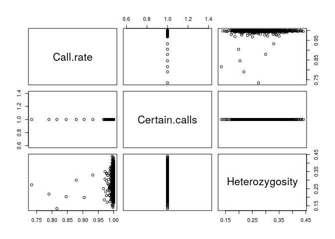

```r
plot(qc.child)
```

2. We don’t want the individuals with a call rate lower than `0.95`:

```r
ok.call.rate <- qc.child$Call.rate >= 0.95
raw.child.ok <- list(genotypes = raw.child$genotypes[ok.call.rate,],
                      fam = raw.child$fam[ok.call.rate,],
                      map = raw.child$map)
str(raw.child.ok)
```

```
## List of 3
##  $ genotypes:Formal class 'SnpMatrix' [package "snpStats"] with 1 slot
##   .. ..@ .Data: raw [1:543, 1:193] 01 01 01 01 ...
##   .. .. ..- attr(*, "dimnames")=List of 2
##   .. .. .. ..$ : chr [1:543] "1_1" "2_1" "3_1" "4_1" ...
##   .. .. .. ..$ : chr [1:193] "rs1" "rs3" "rs5" "rs6" ...
##  $ fam      :'data.frame':   543 obs. of  6 variables:
##   ..$ pedigree: Factor w/ 550 levels "1","10","100",..: 1 112 223 334 445 507 518 529 540 2 ...
##   ..$ member  : Factor w/ 1659 levels "1_1","1_2","1_3",..: 1 338 673 1007 1341 1527 1560 1593 1626 4 ...
##   ..$ father  : Factor w/ 550 levels "1_3","10_3","100_3",..: 1 112 223 334 445 507 518 529 540 2 ...
##   ..$ mother  : Factor w/ 550 levels "1_2","10_2","100_2",..: 1 112 223 334 445 507 518 529 540 2 ...
##   ..$ sex     : num [1:543] 2 1 1 1 2 1 2 2 2 1 ...
##   ..$ affected: num [1:543] 1 0 0 1 1 1 1 0 1 1 ...
##  $ map      :'data.frame':   193 obs. of  5 variables:
##   ..$ chromosome: int [1:193] 1 1 1 1 1 1 1 1 1 1 ...
##   ..$ snp.names : Factor w/ 429 levels "rs1","rs10","rs100",..: 1 136 278 341 407 413 421 2 11 20 ...
##   ..$ position  : int [1:193] 0 0 0 0 0 0 0 0 0 0 ...
##   ..$ allele.1  : chr [1:193] "G" "T" "A" "C" ...
##   ..$ allele.2  : chr [1:193] "C" "A" "T" "G" ...
```

3. Summary of the genetic data, per marker:

```r
qc.child.marker <- col.summary(raw.child.ok$genotypes)
summary(qc.child.marker)
```

```
##      Calls         Call.rate      Certain.calls      RAF
##  Min.   :463.0   Min.   :0.8527   Min.   :1     Min.   :0.01299
##  1st Qu.:542.0   1st Qu.:0.9982   1st Qu.:1     1st Qu.:0.14180
##  Median :543.0   Median :1.0000   Median :1     Median :0.36255
##  Mean   :541.5   Mean   :0.9973   Mean   :1     Mean   :0.38677
##  3rd Qu.:543.0   3rd Qu.:1.0000   3rd Qu.:1     3rd Qu.:0.57934
##  Max.   :543.0   Max.   :1.0000   Max.   :1     Max.   :0.93370
##       MAF               P.AA               P.AB              P.BB
##  Min.   :0.01299   Min.   :0.003683   Min.   :0.02597   Min.   :0.00000
##  1st Qu.:0.13076   1st Qu.:0.173112   1st Qu.:0.22284   1st Qu.:0.02399
##  Median :0.24494   Median :0.416206   Median :0.35175   Median :0.14022
##  Mean   :0.25545   Mean   :0.447596   Mean   :0.33127   Mean   :0.22113
##  3rd Qu.:0.38766   3rd Qu.:0.740332   3rd Qu.:0.45672   3rd Qu.:0.35240
##  Max.   :0.49724   Max.   :0.974026   Max.   :0.52118   Max.   :0.87109
##      z.HWE
##  Min.   :-3.3217
##  1st Qu.:-1.2214
##  Median :-0.4015
##  Mean   :-0.4911
##  3rd Qu.: 0.2179
##  Max.   : 1.8038
```

4. We don’t want the markers with a MAF lower than `0.05`:

```r
ok.MAF <- qc.child.marker$MAF >= 0.05
raw.child.ok <- list(genotypes = raw.child.ok$genotypes[,ok.MAF],
                      fam = raw.child.ok$fam,
                      map = raw.child.ok$map[ok.MAF,])
str(raw.child.ok)
```

```
## List of 3
##  $ genotypes:Formal class 'SnpMatrix' [package "snpStats"] with 1 slot
##   .. ..@ .Data: raw [1:543, 1:179] 02 02 03 02 ...
##   .. .. ..- attr(*, "dimnames")=List of 2
##   .. .. .. ..$ : chr [1:543] "1_1" "2_1" "3_1" "4_1" ...
##   .. .. .. ..$ : chr [1:179] "rs3" "rs5" "rs6" "rs7" ...
##  $ fam      :'data.frame':   543 obs. of  6 variables:
##   ..$ pedigree: Factor w/ 550 levels "1","10","100",..: 1 112 223 334 445 507 518 529 540 2 ...
##   ..$ member  : Factor w/ 1659 levels "1_1","1_2","1_3",..: 1 338 673 1007 1341 1527 1560 1593 1626 4 ...
##   ..$ father  : Factor w/ 550 levels "1_3","10_3","100_3",..: 1 112 223 334 445 507 518 529 540 2 ...
##   ..$ mother  : Factor w/ 550 levels "1_2","10_2","100_2",..: 1 112 223 334 445 507 518 529 540 2 ...
##   ..$ sex     : num [1:543] 2 1 1 1 2 1 2 2 2 1 ...
##   ..$ affected: num [1:543] 1 0 0 1 1 1 1 0 1 1 ...
##  $ map      :'data.frame':   179 obs. of  5 variables:
##   ..$ chromosome: int [1:179] 1 1 1 1 1 1 1 1 1 1 ...
##   ..$ snp.names : Factor w/ 429 levels "rs1","rs10","rs100",..: 136 278 341 407 413 421 2 11 20 29 ...
##   ..$ position  : int [1:179] 0 0 0 0 0 0 0 0 0 0 ...
##   ..$ allele.1  : chr [1:179] "T" "A" "C" "C" ...
##   ..$ allele.2  : chr [1:179] "A" "T" "G" "G" ...
```

### Exercise 6

6.1 Remove the *markers* with a call rate lower than `0.99`:

6.2 How many individuals and markers remain?

# PART 3

## Association analyses in snpStats

1. Prepare the “clean” data for `single.snp.tests()`.

```r
support.data <- data.frame(cc = raw.child.ok$fam$affected)
rownames(support.data) <- rownames(raw.child.ok$fam)
head(support.data)
```

```
##     cc
## 1_1  1
## 2_1  0
## 3_1  0
## 4_1  1
## 5_1  1
## 6_1  1
```

2. Run the analysis.

```r
gwa.child <- single.snp.tests(phenotype = cc,
                               data = support.data,
                               snp.data = raw.child.ok$genotypes)
summary(gwa.child)
```

```
##        N         Chi.squared.1.df   Chi.squared.2.df        P.1df
##  Min.   :463.0   Min.   :0.000057   Min.   : 0.001707   Min.   :0.01581
##  1st Qu.:542.0   1st Qu.:0.102664   1st Qu.: 0.480166   1st Qu.:0.38385
##  Median :543.0   Median :0.321956   Median : 1.213331   Median :0.57043
##  Mean   :541.5   Mean   :0.673731   Mean   : 1.708935   Mean   :0.55463
##  3rd Qu.:543.0   3rd Qu.:0.758433   3rd Qu.: 2.512277   3rd Qu.:0.74866
##  Max.   :543.0   Max.   :5.823478   Max.   :12.646170   Max.   :0.99398
##      P.2df
##  Min.   :0.001794
##  1st Qu.:0.284774
##  Median :0.545166
##  Mean   :0.537120
##  3rd Qu.:0.786571
##  Max.   :0.999147
```

3. Make QQ-plot.

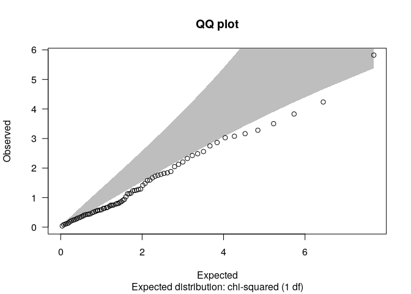

```
##           N     omitted      lambda
## 179.0000000   0.0000000   0.7991755
```

```r
chi2 <- chi.squared(gwa.child, df = 1)
qq.chisq(chi2, df = 1)
```

4. Retrieve p-values.

```r
pval <- p.value(gwa.child, df = 1)
head(sort(pval), 20)
```

```
##      rs283      rs176      rs258        rs9      rs227       rs63      rs250
## 0.01581364 0.03958302 0.05034560 0.06127947 0.07013713 0.07528907 0.07939019
##        rs3      rs181       rs19      rs247      rs264      rs230       rs32
## 0.08186758 0.09061798 0.09732142 0.10969309 0.11498103 0.11951170 0.12741026
##      rs161      rs229      rs126      rs177      rs192       rs55
## 0.13765377 0.14484085 0.15238453 0.16990444 0.17520211 0.17736579
```

5. Find the most signif.SNPs

```r
ord <- order(pval)
top10 <- head(ord, 10)
top10
```

```
##  [1] 167 118 157   6 140  47 155   1 123  14
```

```r
top10.names <- gwa.child@snp.names[top10]
top10.names
```

```
##  [1] "rs283" "rs176" "rs258" "rs9"   "rs227" "rs63"  "rs250" "rs3"   "rs181"
## [10] "rs19"
```

### Exercise 7

7.1 Repeat steps 3 to 5 using the p-values for the test with 2 df. Store the new p-values in pval2.

```r
chi2.2df <- chi.squared(gwa.child, df = 2)
```

7.2 How many SNPs were in the top 10 using both methods?

7.3 Plot pval vs. pval2

7.4 Use `abline` to draw a straight line through the plot with `intercept = 0` and `slope = 1`. How would you interpret this line?